# Competencia ciencia de datos

Los lineplot anteriores muestran información relacionada a Planed_Delivery_Start_Date, falta Planed_Delivery_End_Date, nos fijamos si hay alguna relación entre estas dos variables, vemos si el tiempo que pasa entre Planed_Delivery_Start_Date y Planed_Delivery_End_Date (el "margen") tiene alguna influencia.

```python
dates_analysis['Planned_Delivery_Marg'] = dates_analysis.Planned_Delivery_End_Date - dates_analysis.Planned_Delivery_Start_Date
```

```python
dates_analysis['Planned_Delivery_Marg'].describe()
```

```
count                       16808
mean      22 days 19:42:07.367920
std      537 days 08:20:50.767566
min               0 days 00:00:00
25%               0 days 00:00:00
50%               4 days 00:00:00
75%              24 days 00:00:00
max           69474 days 00:00:00
Name: Planned_Delivery_Marg, dtype: object
```

```python
dates_analysis[dates_analysis['Planned_Delivery_Marg'].dt.days.astype(int) > 150].shape
```

```
(257, 9)
```

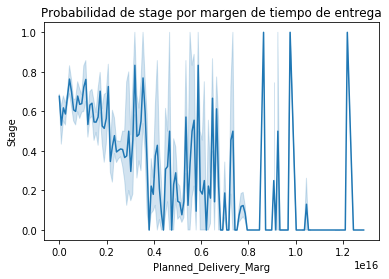

```python
sns.lineplot(x=dates_analysis[dates_analysis['Planned_Delivery_Marg'].dt.days.astype(int) < 150]['Planned_Delivery_Marg'], y=dates_analysis[dates_analysis['Planned_Delivery_Marg'].dt.days.astype(int) < 150]['Stage'])
plt.title("Probabilidad de stage por margen de tiempo de entrega")
plt.show()
```

Otra fecha que parece interesante analizar es **Opportunity_Created_Date**

```python
df.Opportunity_Created_Date.describe()
```

```
count                   16947
unique                   1096
top       2017-06-30 00:00:00
freq                      124
first     2013-11-05 00:00:00
last      2018-12-29 00:00:00
Name: Opportunity_Created_Date, dtype: object
```

Vemos que en este caso los valores vienen desde 2013.

```python
df[df.Opportunity_Created_Date.dt.year.astype(int) < 2015 ].shape
```

```
(41, 52)
```

Muy pocas oportunidades se crearon en años anteriores a 2015. Falta conocimiento del negocio para saber si estos datos son erroneos, o simplemente en esos años hubo muy pocas oportunidades.

```python
dates_analysis = df[['Opportunity_Created_Date','Planned_Delivery_Start_Date','Stage']]
dates_analysis['Stage'] = dates_analysis.Stage.map(target_map)
dates_analysis = dates_analysis.dropna()
dates_analysis['Created_Month'] = dates_analysis.Opportunity_Created_Date.dt.month
dates_analysis['Created_Year'] = dates_analysis.Opportunity_Created_Date.dt.year
dates_analysis['Created_Day_Of_Month'] = dates_analysis.Opportunity_Created_Date.dt.day
dates_analysis['Created_Day_Of_Week'] = dates_analysis.Opportunity_Created_Date.dt.weekday
dates_analysis['Created_Quarter'] = dates_analysis.Opportunity_Created_Date.dt.quarter
```

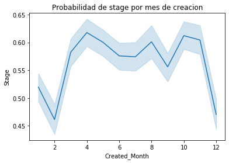

```python
sns.lineplot(x=dates_analysis['Created_Month'], y=dates_analysis['Stage'])
plt.title("Probabilidad de stage por mes de creacion")
plt.show()
```

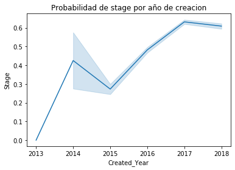

```python
sns.lineplot(x=dates_analysis['Created_Year'], y=dates_analysis['Stage'])
plt.title("Probabilidad de stage por año de creacion")
plt.show()
```

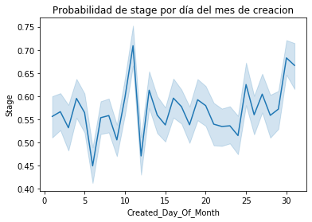

```python
sns.lineplot(x=dates_analysis['Created_Day_Of_Month'], y=dates_analysis['Stage'])
plt.title("Probabilidad de stage por día del mes de creacion")
plt.show()
```

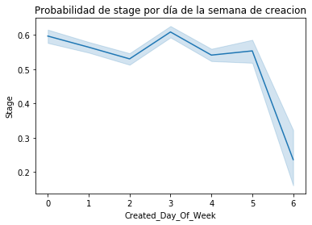

```python
sns.lineplot(x=dates_analysis['Created_Day_Of_Week'], y=dates_analysis['Stage'])
plt.title("Probabilidad de stage por día de la semana de creacion")
plt.show()
```

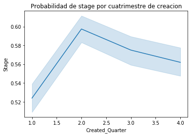

```python
sns.lineplot(x=dates_analysis['Created_Quarter'], y=dates_analysis['Stage'])
plt.title("Probabilidad de stage por cuatrimestre de creacion")
plt.show()
```

Cuatrimestre y año parecen ser las variables más relevantes.

Analizamos la fecha **Quote_Expiry_Date**: tendrá alguna relación con Stage? El tiempo que pasa entre que se crea la oportunidad y la fecha de expiración del presupuesto, influirá?

```python
df['Quote_Expiry_Date'].describe()
```

```
count                   12322
unique                   1002
top       2017-06-30 00:00:00
freq                      436
first     2014-09-30 00:00:00
last      2019-06-30 00:00:00
Name: Quote_Expiry_Date, dtype: object
```

```python
dates_analysis = df[['Opportunity_Created_Date','Quote_Expiry_Date','Stage']]
dates_analysis['Stage'] = dates_analysis.Stage.map(target_map)
dates_analysis = dates_analysis.dropna()
dates_analysis['Expiry_Month'] = dates_analysis.Quote_Expiry_Date.dt.month
dates_analysis['Expiry_Year'] = dates_analysis.Quote_Expiry_Date.dt.year
dates_analysis['Expiry_Quarter'] = dates_analysis.Quote_Expiry_Date.dt.quarter
```

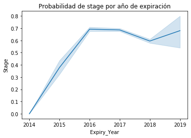

```python
sns.lineplot(x=dates_analysis['Expiry_Year'], y=dates_analysis['Stage'])
plt.title("Probabilidad de stage por año de expiración")
plt.show()
```

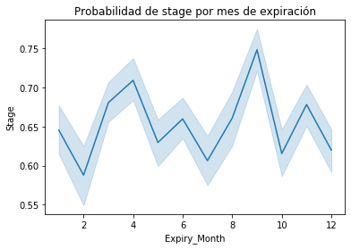

```python
sns.lineplot(x=dates_analysis['Expiry_Month'], y=dates_analysis['Stage'])
plt.title("Probabilidad de stage por mes de expiración")
plt.show()
```

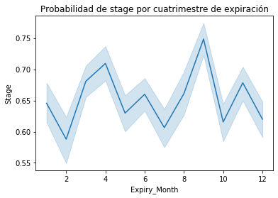

```python
sns.lineplot(x=dates_analysis['Expiry_Month'], y=dates_analysis['Stage'])
plt.title("Probabilidad de stage por cuatrimestre de expiración")
plt.show()
```

```python
dates_analysis['Expiry_Created_Margin'] = dates_analysis.Quote_Expiry_Date - dates_analysis.Opportunity_Created_Date
```

```python
dates_analysis['Expiry_Created_Margin'].describe()
```

```
count                      12289
mean     46 days 22:28:57.163316
std      77 days 18:53:40.303540
min         -1040 days +00:00:00
25%              7 days 00:00:00
50%             27 days 00:00:00
75%             57 days 00:00:00
max           1798 days 00:00:00
Name: Expiry_Created_Margin, dtype: object
```

```python
dates_analysis[dates_analysis['Expiry_Created_Margin'].dt.days.astype(int) > 365].shape
```

```
(115, 7)
```

```python
dates_analysis[dates_analysis['Expiry_Created_Margin'].dt.days.astype(int) < 0].shape
```

```
(105, 7)
```

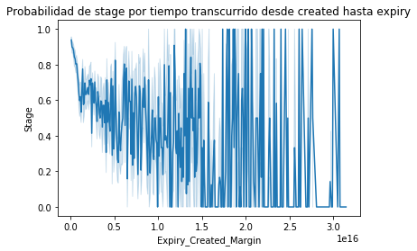

```python
dates_analysis[dates_analysis['Expiry_Created_Margin'].dt.days.astype(int) > 150].shape
sns.lineplot(x=dates_analysis[(dates_analysis['Expiry_Created_Margin'].dt.days.astype(int) < 365) & (dates_analysis['Expiry_Created_Margin'].dt.days.astype(int) > 0)]['Expiry_Created_Margin'],
             y=dates_analysis[(dates_analysis['Expiry_Created_Margin'].dt.days.astype(int) < 365) & (dates_analysis['Expiry_Created_Margin'].dt.days.astype(int) > 0)]['Stage'])
plt.title("Probabilidad de stage por tiempo transcurrido desde created hasta expiry")
plt.show()
```

No se encuentra una relación muy importante.

Para el caso de Actual_Delivery_Date vemos que en el 100% de sus casos el valor es NaT. Claramente esta variable aunque la tuviesemos no debería ser utilizada para entrenar un modelo predictivo, ya que al momento de predecir no tenemos la fecha REAL de entrega, podemos tener la fecha planeada.

### Variables continuas

Tenemos variables relacionadas al precio como Total*Amount y ASP. Una variable que puede llegar a ser muy útil es **ASP*(converted)** que está convertido a dolares.

También analizamos variables como el Total_Taxable_Amount y TRF que representa las toneladas de refrigeración.

```python
cont_analysis = df[['Price','ASP','ASP_(converted)','TRF','Total_Amount','Product_Name','Total_Amount_Currency','Total_Taxable_Amount','Stage']]
cont_analysis = cont_analysis[cont_analysis.Stage.isin(interest_stages)]
cont_analysis['Stage'] = cont_analysis.Stage.map(target_map)
cont_analysis.head()
```

|  | Price | ASP | ASP_(converted) | TRF | Total_Amount | Product_Name | Total_Amount_Currency | Total_Taxable_Amount | Stage |
| --- | --- | --- | --- | --- | --- | --- | --- | --- | --- |
| 0 | None | 0.52 | 0.58817 | 10 | 5272800.0 | Product_Name_99 | EUR | 5272800.0 | 0 |
| 1 | None | 0.53 | 0.59948 | 0 | 48230.0 | Product_Name_100 | EUR | 48230.0 | 1 |
| 2 | None | 0.48 | 0.48000 | 0 | 83865.6 | Product_Name_91 | USD | 83865.6 | 1 |
| 3 | 0.42 | 0.53 | 0.53000 | 14 | 7421881.5 | Product_Name_432 | USD | 7421881.5 | 0 |
| 4 | 0.42 | 0.53 | 0.53000 | 25 | 13357192.5 | Product_Name_432 | USD | 13357192.5 | 0 |

Comenzamos con **TRF**:

```python
cont_analysis.TRF.describe()
```

```
count    16883.000000
mean         2.335841
std         12.186565
min          0.000000
25%          0.000000
50%          0.000000
75%          1.000000
max        500.000000
Name: TRF, dtype: float64
```

```python
cont_analysis[cont_analysis.TRF == 0].shape
```

```
(11942, 9)
```

El valor 0 es muy frecuente en esta columna. Sería bueno conocer un poco más sobre el negocio y ver si esto se debe a que el producto no se vende por TRF, si son valores faltantes, o a que se deben estos 0s. Por el momento, analizamos con los conocimientos que se tienen en el momento, nos fijamos si hay alguna tendencia en estos TRF = 0.

```python
zero_trf = cont_analysis[cont_analysis.TRF == 0]
zero_trf.Stage.value_counts()
```

```
1    8236
0    3706
Name: Stage, dtype: int64
```

```python
zero_trf_product_names = zero_trf.Product_Name.unique()
```

```python
print("Cantidad de productos que tienen algún caso de TRF = 0: "+ str(zero_trf_product_names.shape[0]))
```

```
Cantidad de productos que tienen algún caso de TRF = 0: 216
```

```python
print("Cantidad de productos en el total del dataframe:"+ str(cont_analysis.Product_Name.nunique()))
```

```
Cantidad de productos en el total del dataframe:446
```

Nos fijamos si esos productos en los que TRF era 0, tienen algún caso en el que TRF sea distinto de 0:

```python
cont_analysis[(cont_analysis.Product_Name.isin(zero_trf_product_names)) & (cont_analysis.TRF != 0)].shape
```

```
(0, 9)
```

```python
cont_analysis[cont_analysis.Product_Name.isin(zero_trf_product_names)].TRF.value_counts()
```

```
0    11942
Name: TRF, dtype: int64
```

Parece que en estos 216 productos el valor de TRF es siempre = 0. Puede deberse a que este producto no se venda por TRF entonces. De todas formas no podemos estar 100% seguros ya que hasta donde se explica en la descripción de la competencia, estos equipos son de refrigeración y se venden por toneladas de refrigeración.

Comenzamos con el análisis del precio promedio de venta:

```python
df['ASP_(converted)'].describe()
```

```
count    13738.000000
mean         0.432554
std          0.758659
min          0.000000
25%          0.373260
50%          0.412850
75%          0.476490
max         67.000000
Name: ASP_(converted), dtype: float64
```

```python
df['ASP'].describe()
```

```
count    13738.000000
mean         7.012128
std         18.858359
min          0.000000
25%          0.360000
50%          0.400000
75%          0.505000
max         80.000000
Name: ASP, dtype: float64
```

```python
df[df['ASP_(converted)'] < 0]
```

|  | ID | Region | Territory | Pricing, Delivery_Terms_Quote_Appr | Pricing, Delivery_Terms_Approved | Bureaucratic_Code_0_Approval | Bureaucratic_Code_0_Approved | Submitted_for_Approval | Bureaucratic_Code | Account_Created_Date | Source | Billing_Country | Account_Name | Opportunity_Name | Opportunity_ID | Sales_Contract_No | Account_Owner | Opportunity_Owner | Account_Type | Opportunity_Type | Quote_Type | Delivery_Terms | Opportunity_Created_Date | Brand | Product_Type | Size | Product_Category_B | Price | Currency | … |
| --- | --- | --- | --- | --- | --- | --- | --- | --- | --- | --- | --- | --- | --- | --- | --- | --- | --- | --- | --- | --- | --- | --- | --- | --- | --- | --- | --- | --- | --- | --- |

```python
df[df['ASP_(converted)'] > 1]
```

|  | ID | Region | Territory | Pricing, Delivery_Terms_Quote_Appr | Pricing, Delivery_Terms_Approved | Bureaucratic_Code_0_Approval | Bureaucratic_Code_0_Approved | Submitted_for_Approval | Bureaucratic_Code | Account_Created_Date | Source | Billing_Country | Account_Name | Opportunity_Name | Opportunity_ID | Sales_Contract_No | Account_Owner | Opportunity_Owner | Account_Type | Opportunity_Type | Quote_Type | Delivery_Terms | Opportunity_Created_Date | Brand | Product_Type | Size | Product_Category_B | Price | Currency | … |
| --- | --- | --- | --- | --- | --- | --- | --- | --- | --- | --- | --- | --- | --- | --- | --- | --- | --- | --- | --- | --- | --- | --- | --- | --- | --- | --- | --- | --- | --- | --- |
| 2179 | 10808 | EMEA | None | 1 | 1 | 1 | 1 | 0 | Bureaucratic_Code_4 | 2016-02-17 | None | Belgium | Account_Name_2059 | Opportunity_Name_5264 | 1235 | None | Person_Name_51 | Person_Name_18 | Account_Type_0 | Opportunity_Type_19 | Non Binding | Delivery_Terms_2 | 2016-02-17 | None | None | None | None | None | None | … |
| 2200 | 27692 | Japan | None | 1 | 1 | 1 | 1 | 0 | Bureaucratic_Code_4 | 2015-06-11 | Source_3 | Japan | Account_Name_1074 | Opportunity_Name_6550 | 1248 | 116 | Person_Name_61 | Person_Name_66 | Account_Type_0 | Opportunity_Type_1 | Non Binding | Delivery_Terms_5 | 2016-02-19 | None | None | None | None | None | None | … |
| 16114 | 21004 | APAC | Philippines | 0 | 0 | 0 | 0 | 0 | Bureaucratic_Code_1 | 2014-07-11 | None | Philippines | Account_Name_1190 | Opportunity_Name_8894 | 12376 | None | Person_Name_44 | Person_Name_44 | None | Opportunity_Type_19 | Non Binding | Delivery_Terms_1 | 2014-07-11 | None | None | None | None | None | None | … |
| 16117 | 16674 | APAC | Philippines | 1 | 0 | 0 | 0 | 0 | Bureaucratic_Code_5 | 2013-10-03 | None | Singapore | Account_Name_1797 | Opportunity_Name_6659 | 12379 | None | Person_Name_65 | Person_Name_44 | Account_Type_2 | Opportunity_Type_8 | Non Binding | Delivery_Terms_4 | 2014-09-01 | None | None | None | None | None | None | … |
| 16118 | 16678 | APAC | Philippines | 1 | 0 | 0 | 0 | 0 | Bureaucratic_Code_5 | 2013-10-03 | None | Singapore | Account_Name_1797 | Opportunity_Name_6659 | 12379 | None | Person_Name_65 | Person_Name_44 | Account_Type_2 | Opportunity_Type_8 | Non Binding | Delivery_Terms_4 | 2014-09-01 | None | None | None | None | None | None | … |
| 16119 | 16681 | APAC | Philippines | 1 | 0 | 0 | 0 | 0 | Bureaucratic_Code_5 | 2013-10-03 | None | Singapore | Account_Name_1797 | Opportunity_Name_6659 | 12379 | None | Person_Name_65 | Person_Name_44 | Account_Type_2 | Opportunity_Type_8 | Non Binding | Delivery_Terms_4 | 2014-09-01 | None | None | None | None | None | None | … |
| 16120 | 16684 | APAC | Philippines | 1 | 0 | 0 | 0 | 0 | Bureaucratic_Code_5 | 2013-10-03 | None | Singapore | Account_Name_1797 | Opportunity_Name_6659 | 12379 | None | Person_Name_65 | Person_Name_44 | Account_Type_2 | Opportunity_Type_8 | Non Binding | Delivery_Terms_4 | 2014-09-01 | None | None | None | None | None | None | … |
| 16121 | 16688 | APAC | Philippines | 1 | 0 | 0 | 0 | 0 | Bureaucratic_Code_5 | 2013-10-03 | None | Singapore | Account_Name_1797 | Opportunity_Name_6659 | 12379 | None | Person_Name_65 | Person_Name_44 | Account_Type_2 | Opportunity_Type_8 | Non Binding | Delivery_Terms_4 | 2014-09-01 | None | None | None | None | None | None | … |
| 16122 | 16691 | APAC | Philippines | 1 | 0 | 0 | 0 | 0 | Bureaucratic_Code_5 | 2013-10-03 | None | Singapore | Account_Name_1797 | Opportunity_Name_6659 | 12379 | None | Person_Name_65 | Person_Name_44 | Account_Type_2 | Opportunity_Type_8 | Non Binding | Delivery_Terms_4 | 2014-09-01 | None | None | None | None | None | None | … |

```python
df[df['ASP_(converted)'] > 1.7]['ASP_(converted)']
```

```
2179    57.68578
2200    67.00000
Name: ASP_(converted), dtype: float64
```

Ambos (ASP y el convertido) tienen la misma cantidad de nulos. Trabajaremos con el valor convertido a dolares directamente.

Este valor, por lo que se ve en el dataset (en los casos que TRF != 0 ) puede ser calculado como Total_Amount / TRF. Luego estos valores están escalados salvo en estos 2 casos en los que su valor es 57.68578 y 67.00000.

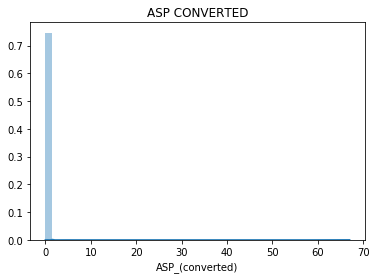

```python
sns.distplot(df['ASP_(converted)'])
plt.title("ASP CONVERTED")
```

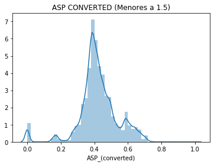

```python
sns.distplot(df[df['ASP_(converted)'] < 1.5]['ASP_(converted)'])
plt.title("ASP CONVERTED (Menores a 1.5)")
```

Analizamos las variables **Total_Amount** y **Total_Taxable_Amount**

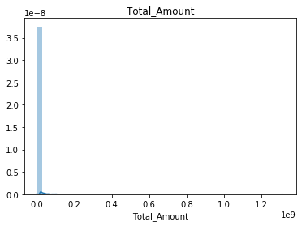

```python
sns.distplot(df['Total_Amount'])
plt.title("Total_Amount")
```

```python
df[df.Total_Amount == 0].shape[0]
```

```
52
```

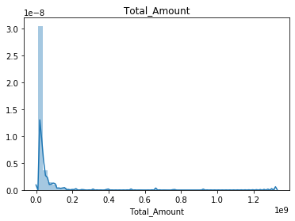

```python
sns.distplot(df[df['Total_Amount'] > 10000000].Total_Amount)
plt.title("Total_Amount")
```

Tenemos una cola muy larga en esta distribución. De todas formas, estos valores están en distintas moneadas por lo que no es muy útil analizarlos a todos en conjunto.

### Correlación

Generamos un heatmap de correlación entre algunas de las variables continuas para ver si aparece alguna multicolinearidad

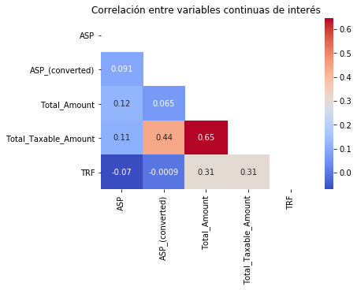

```python
mask = np.zeros_like(df[['ASP','ASP_(converted)','Total_Amount','Total_Taxable_Amount','TRF']].corr(), dtype=np.bool)
mask[np.triu_indices_from(mask)] = True
sns.heatmap(df[['ASP','ASP_(converted)','Total_Amount','Total_Taxable_Amount','TRF']].corr(), annot = True, cmap='coolwarm',mask = mask)
plt.title('Correlación entre variables continuas de interés')
plt.show()
```

# Preprocesamiento

## Train preprocess pipeline

Definimos algunas clases para preprocesar el set de entrenamiento en un pipeline de sklearn:

```python
class UselessDropper( BaseEstimator, TransformerMixin ):
    '''
    Dropear filas que tienen stage != Closed Won y Closed Lost en el set de entrenamiento
    '''
    def __init__( self ):
        pass

    def fit( self, X, y = None ):
        return self

    def transform( self, X, y = None ):
        return X[X.Stage.isin(['Closed Won','Closed Lost'])]
```

```python
class OutliersHandler( BaseEstimator, TransformerMixin):
    '''
    Manejo de outliers en el set de entrenamiento
    '''
    def __init__( self ):
        pass

    def fit( self, X, y = None ):
        return self

    def transform( self, X, y = None ):
        X['ASP_(converted)'] = X['ASP_(converted)'].fillna(X['ASP_(converted)'].mean())
        X = X[X['ASP_(converted)'] != 0]
        X = X[X['ASP_(converted)'] < 1]
        return X
```

```python
class StageEncoder( BaseEstimator, TransformerMixin ):
    '''
    Encoding de la variable a predecir.
    '''
    def __init__( self):
        pass

    def fit( self, X, y = None ):
        return self

    def transform( self, X, y = None ):
        X['Stage'] = X['Stage'].replace({'Closed Won':1,'Closed Lost':0})
        return X
```

# Pipeline

Y las clases para armar el pipeline de preprocesamiento en general:

```python
class ColumnsDropper( BaseEstimator, TransformerMixin ):
    '''
    Dropear columnas que no se usan
    '''
    def __init__( self, features_to_drop ):
        self._features_to_drop = features_to_drop

    def fit( self, X, y = None ):
        return self

    def transform( self, X, y = None ):
        return X.drop(self._features_to_drop,axis=1 )
```

```python
class TotalTaxableAmountCalculator( BaseEstimator, TransformerMixin ):
    '''
    Porcentaje del total_amount que tiene impuestos.
    '''
    def __init__( self):
        pass

    def fit( self, X, y = None ):
        return self

    def transform( self, X, y = None ):
        X = X.dropna(subset=['Total_Amount','Total_Taxable_Amount'])
        X['Taxable_Amount_Percentage'] = X.Total_Amount / X.Total_Taxable_Amount
        X['Taxable_Amount_Percentage'] = X['Taxable_Amount_Percentage'].replace(np.inf, 0)
        X['Taxable_Amount_Percentage'] = X['Taxable_Amount_Percentage'].fillna(0)
        X = X.drop(['Total_Amount','Total_Taxable_Amount'], axis=1)
        return X
```

```python
class TimeElapsedCalculator( BaseEstimator, TransformerMixin ):
    '''
    Se calcula el tiempo transcurrido desde que se crea la oportunidad hasta que expira el presupuesto.
    '''
    def __init__( self):
        pass

    def fit( self, X, y = None ):
        return self

    def transform( self, X, y = None ):
        X['Quote_Expiry_Date'] = X['Quote_Expiry_Date'].fillna(X.Opportunity_Created_Date)
        X['created_to_expiry_days'] = X.Quote_Expiry_Date - X.Opportunity_Created_Date
        X['created_to_expiry_days'] = X['created_to_expiry_days'].dt.days.astype('int16')
        X = X[X['created_to_expiry_days'] >= 0]
        return X.drop(['Quote_Expiry_Date','Opportunity_Created_Date'], axis=1)
```

```python
class PlannedDeliveryDateProcessor( BaseEstimator, TransformerMixin ):
    '''
    Se obtienen distintas features de la fecha de entrega.
    '''
    def __init__( self):
        pass

    def fit( self, X, y = None ):
        return self

    def transform( self, X, y = None ):
        #X['Planned_Delivery_Month'] = X.Planned_Delivery_Start_Date.dt.month
        X['Planned_Delivery_Year'] = X.Planned_Delivery_Start_Date.dt.year
        #X['Planned_Delivery_Day_Of_Month'] = X.Planned_Delivery_Start_Date.dt.day
        #X['Planned_Delivery_Day_Of_Week'] = X.Planned_Delivery_Start_Date.dt.weekday
        X['Planned_Delivery_Quarter'] = X.Planned_Delivery_Start_Date.dt.quarter
        X = X.drop('Planned_Delivery_Start_Date', axis=1)
        return X
```

```python
class CreatedDateProcessor( BaseEstimator, TransformerMixin ):
    '''
    Se obtienen distintas features de la fecha de creación.
    '''
    def __init__( self):
        pass

    def fit( self, X, y = None ):
        return self

    def transform( self, X, y = None ):
        #X['Created_Month'] = X.Opportunity_Created_Date.dt.month
        X['Created_Year'] = X.Opportunity_Created_Date.dt.year
        X['Created_Quarter'] = X.Opportunity_Created_Date.dt.quarter
        X = X.drop('Opportunity_Created_Date', axis=1)
        return X
```

```python
class SalesContractTransformer( BaseEstimator, TransformerMixin ):
    '''
    Se rempazan los None por 0.
    Esta variable es un caso de Target Lekeage. Solo se utiliza en un modelo para demostrar como
    incluyendola en el entrenamiento, se puede obtener un muy buen puntaje.
    '''
    def __init__( self ):
        pass

    def fit( self, X, y = None ):
        return self

    def transform( self, X, y = None ):
        X['Sales_Contract_No'] = X['Sales_Contract_No'].replace('None', 0).astype(int)
        return X
```

```python
class ProductCategoryBTransformer( BaseEstimator, TransformerMixin ):
    '''
    Dejamos esta variable simplemente como 1 (si tiene alguna category B) o 0 (si el valor es 'None')
    '''
    def __init__( self):
        pass

    def fit( self, X, y = None ):
        return self

    def transform( self, X, y = None ):
        X['Product_Category_B'] = X['Product_Category_B'] != 'None'
        X['Product_Category_B'] = X['Product_Category_B'].map({False:0, True:1})
        return X
```

```python
class Encoder( BaseEstimator, TransformerMixin ):
    def __init__( self):
        self.region_encoder = TargetEncoder()
        self.bureaucratic_code_encoder = TargetEncoder()
        self.account_owner_encoder = TargetEncoder()
        self.account_type_encoder = TargetEncoder()
        self.opportunity_type_encoder = TargetEncoder()
        self.product_name_encoder = TargetEncoder()
        self.last_modified_by_encoder = TargetEncoder()
        self.opportunity_owner_encoder = TargetEncoder()
        pass

    def fit( self, X, y = None ):
        y = X['Stage']
        self.region_encoder.fit(X['Region'],y)
        self.bureaucratic_code_encoder.fit(X['Bureaucratic_Code'],y)
        self.account_owner_encoder.fit(X['Account_Owner'],y)
        self.account_type_encoder.fit(X['Account_Type'],y)
        self.opportunity_type_encoder.fit(X['Opportunity_Type'],y)
        self.product_name_encoder.fit(X['Product_Name'],y)
        self.last_modified_by_encoder.fit(X['Last_Modified_By'],y)
        self.opportunity_owner_encoder.fit(X['Opportunity_Owner'],y)
        return self

    def transform( self, X, y = None ):
        X['Region'] = self.region_encoder.transform(X['Region'])
        X['Bureaucratic_Code'] = self.bureaucratic_code_encoder.transform(X['Bureaucratic_Code'])
        X['Account_Owner'] = self.account_owner_encoder.transform(X['Account_Owner'])
        X['Account_Type'] = self.account_type_encoder.transform(X['Account_Type'])
        X['Opportunity_Type'] = self.opportunity_type_encoder.transform(X['Opportunity_Type'])
        X['Product_Name'] = self.product_name_encoder.transform(X['Product_Name'])
        X['Last_Modified_By'] = self.last_modified_by_encoder.transform(X['Last_Modified_By'])
        X['Opportunity_Owner'] = self.opportunity_owner_encoder.transform(X['Opportunity_Owner'])
        return X
```

```python
train_df, test_df = train_test_split(df, test_size=0.2)
```

```python
drop_features= ['Opportunity_ID','Last_Activity','ASP_(converted)_Currency','Quote_Type','Delivery_Quarter',
                'Source ','Account_Created_Date','ASP','Last_Modified_Date','Actual_Delivery_Date', 'Sales_Contract_No','TRF',
                'Total_Amount_Currency','Month','Delivery_Year','Territory','Submitted_for_Approval', 'Brand',
                'Currency', 'Quote_Expiry_Date','Total_Taxable_Amount_Currency','Opportunity_Name','Billing_Country',
                'ASP_Currency', 'ASP_(converted)',
                'Prod_Category_A','Month','Product_Family','Price','Size','ID','Planned_Delivery_End_Date','Account_Name','Delivery_Terms','Product_Type']

train_preprocessing_pipeline = Pipeline( steps = [('useless_dropper', UselessDropper()),
                                                 ('outliers_handler', OutliersHandler()),
                                                 ('stage_encoder', StageEncoder())])

preprocessing_pipeline = Pipeline( steps = [ ('columns_dropper', ColumnsDropper(drop_features)),
                                             ('taxable_amount', TotalTaxableAmountCalculator()),
                                             ('created_date_proc', CreatedDateProcessor()),
                                             ('planned_del_date_proc', PlannedDeliveryDateProcessor()),
                                             ('prod_cat_B', ProductCategoryBTransformer()),
                                             ('target_encoder',Encoder())
                                            ] )

drop_features_lekeage = drop_features.copy()
drop_features_lekeage.remove('Sales_Contract_No')

lekeage_pipeline = Pipeline( steps = [ ('columns_dropper', ColumnsDropper(drop_features_lekeage)),
                                       ('taxable_amount', TotalTaxableAmountCalculator()),
                                       ('created_date_proc', CreatedDateProcessor()),
                                       ('planned_del_date_proc', PlannedDeliveryDateProcessor()),
                                       ('sales_contract', SalesContractTransformer()),
                                       ('prod_cat_B', ProductCategoryBTransformer()),
                                       ('target_encoder',Encoder())
                                    ] )
```

```python
train_df = train_preprocessing_pipeline.fit_transform(train_df)
test_df = train_preprocessing_pipeline.fit_transform(test_df)
```

```python
preproc_train_df = preprocessing_pipeline.fit_transform(train_df).dropna()
preproc_test_df = preprocessing_pipeline.transform(test_df)

preproc_train_l = lekeage_pipeline.fit_transform(train_df).dropna()
preproc_test_l = lekeage_pipeline.transform(test_df)
```

```python
X_train = preproc_train_df.drop('Stage',axis=1)
X_test = preproc_test_df.drop('Stage',axis=1)

X_train_l = preproc_train_l.drop('Stage',axis=1)
X_test_l = preproc_test_l.drop('Stage',axis=1)

y_train = preproc_train_df['Stage']
y_test = preproc_test_df['Stage']

y_train_l = preproc_train_l['Stage']
y_test_l = preproc_test_l['Stage']
```

```python
X_train.head()
```

|  | Region | Pricing, Delivery_Terms_Quote_Appr | Pricing, Delivery_Terms_Approved | Bureaucratic_Code_0_Approval | Bureaucratic_Code_0_Approved | Bureaucratic_Code | Account_Owner | Opportunity_Owner | Account_Type | Opportunity_Type | Product_Category_B | Last_Modified_By | Product_Name | Taxable_Amount_Percentage | Created_Year | Created_Quarter | Planned_Delivery_Year | Planned_Delivery_Quarter |
| --- | --- | --- | --- | --- | --- | --- | --- | --- | --- | --- | --- | --- | --- | --- | --- | --- | --- | --- |
| 2857 | 0.667838 | 1 | 0 | 0 | 0 | 0.265929 | 0.643398 | 0.643303 | 0.541336 | 0.671365 | 0 | 0.503219 | 0.606742 | 0.027773 | 2016 | 2 | 2016 | 2 |
| 12147 | 0.459968 | 1 | 0 | 1 | 0 | 0.265929 | 0.325000 | 0.653753 | 0.541336 | 0.531420 | 0 | 0.788856 | 0.592814 | 0.991510 | 2018 | 1 | 2018 | 3 |
| 1372 | 0.583846 | 1 | 0 | 1 | 0 | 0.265929 | 0.524691 | 0.500000 | 0.541336 | 0.531420 | 0 | 0.653875 | 0.560627 | 1.000000 | 2017 | 1 | 2017 | 3 |
| 10405 | 0.459968 | 1 | 1 | 1 | 1 | 0.651762 | 0.262700 | 0.283763 | 0.307895 | 0.531420 | 0 | 0.788856 | 0.313131 | 1.000000 | 2017 | 4 | 2018 | 3 |
| 5403 | 0.529970 | 1 | 0 | 1 | 0 | 0.265929 | 0.674419 | 0.667319 | 0.307895 | 0.211297 | 0 | 0.601307 | 0.192308 | 1.000000 | 2016 | 4 | 2017 | 4 |

```python
X_train.shape
```

```
(13212, 18)
```

# Target Lekeage

```python
xgb = XGBClassifier(alpha=0.4, gamma=2.8, importance_type='gain',
                    learning_rate=0.009, max_delta_step=0, max_depth=14,
                    min_child_weight=1, n_estimators=1200, n_jobs=-1,
                    reg_alpha=0.4, reg_lambda=1.4, sampling_method='gradient_based',
                    tree_method='exact')
xgb.fit(X_train_l, y_train_l)
```

```
XGBClassifier(alpha=0.4, base_score=0.5, booster='gbtree', colsample_bylevel=1,
              colsample_bynode=1, colsample_bytree=1, gamma=2.8,
              learning_rate=0.009, max_delta_step=0, max_depth=14,
              min_child_weight=1, missing=None, n_estimators=1200, n_jobs=-1,
              nthread=None, objective='binary:logistic', random_state=0,
              reg_alpha=0.4, reg_lambda=1.4, sampling_method='gradient_based',
              scale_pos_weight=1, seed=None, silent=None, subsample=1,
              tree_method='exact', verbosity=1)
```

```python
log_loss(y_train_l, xgb.predict_proba(X_train_l))
```

```
0.05138202820202959
```

```python
log_loss(y_test_l, xgb.predict_proba(X_test_l))
```

```
0.07678360282985094
```

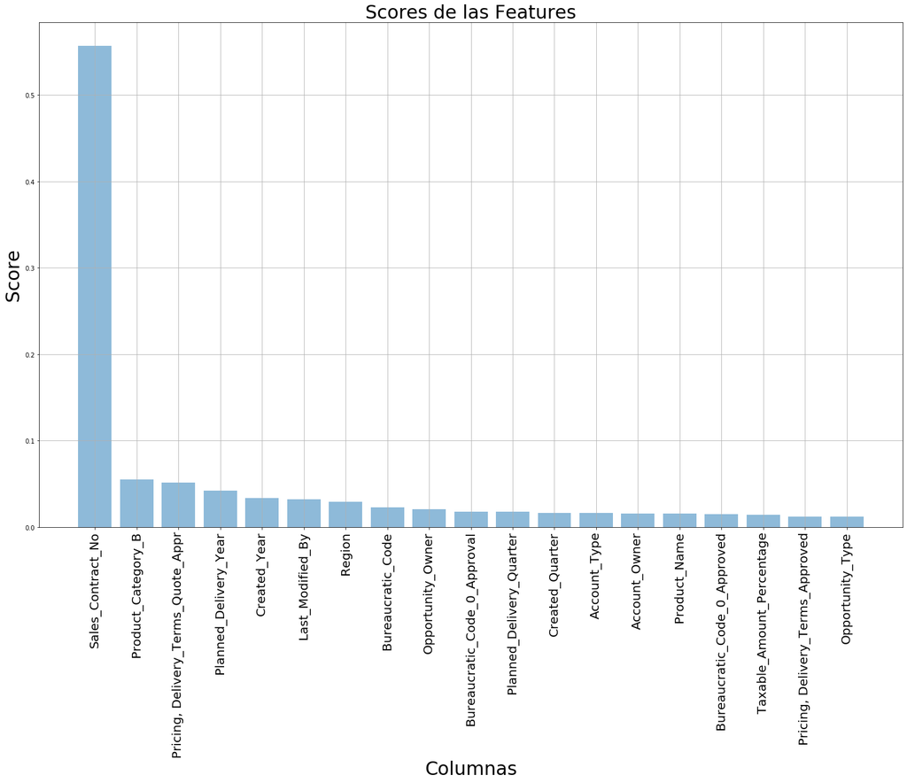

```python
columnas = X_train_l.columns.array
valores = xgb.feature_importances_
df_scores =pd.DataFrame({'Feat':columnas, 'Score':valores})
df_scores = df_scores.sort_values("Score", ascending = False)
fig, ax = plt.subplots(figsize=(25, 15))


objects = df_scores["Feat"]
y_pos = np.arange(len(objects))
performance = df_scores["Score"]

plt.bar(y_pos, performance, align='center', alpha=0.5)
plt.xticks(y_pos, objects, fontsize =20, rotation = 90)

plt.grid()
plt.title("Scores de las Features", fontsize=30)
plt.xlabel("Columnas", fontsize=30)
plt.ylabel("Score", fontsize=30)

plt.show()
```

Se puede ver claramente como la variable Sales_Contract_No influye sobre el resultado, mejorando muchisimo el score. Sin embargo, esto no sirve ya que no es una variable que vayamos a tener en la realidad cuando querramos usar el modelo.

# XGB Classifier

```python
df[df.Stage == 'Closed Won'].shape[0]
```

```
9533
```

```python
df[df.Stage == 'Closed Lost'].shape[0]
```

```
7350
```

**scale_pos_weight**: Control the balance of positive and negative weights, useful for unbalanced classes. A typical value to consider: sum(negative instances) / sum(positive instances).

```python
scale_pos_weight = df[df.Stage == 'Closed Lost'].shape[0] / df[df.Stage == 'Closed Won'].shape[0]
```

```python
scale_pos_weight
```

```
0.771005979230043
```

```python
xgb = XGBClassifier(alpha=0.5, gamma=4.5, importance_type='gain',
                    learning_rate=0.01, max_depth=6,
                    min_child_weight=1, n_estimators=2500, n_jobs=-1,
                    reg_alpha=0.5, reg_lambda=1.5, sampling_method='gradient_based',
                    scale_pos_weight= scale_pos_weight, tree_method='exact')
xgb.fit(X_train, y_train)
```

```
XGBClassifier(alpha=0.5, base_score=0.5, booster='gbtree', colsample_bylevel=1,
              colsample_bynode=1, colsample_bytree=1, gamma=4.5,
              learning_rate=0.01, max_delta_step=0, max_depth=6,
              min_child_weight=1, missing=None, n_estimators=2500, n_jobs=-1,
              nthread=None, objective='binary:logistic', random_state=0,
              reg_alpha=0.5, reg_lambda=1.5, sampling_method='gradient_based',
              scale_pos_weight=0.771005979230043, seed=None, silent=None,
              subsample=1, tree_method='exact', verbosity=1)
```

```python
log_loss(y_train, xgb.predict_proba(X_train))
```

```
0.2985165922670187
```

```python
log_loss(y_test, xgb.predict_proba(X_test))
```

```
0.31505332159615623
```

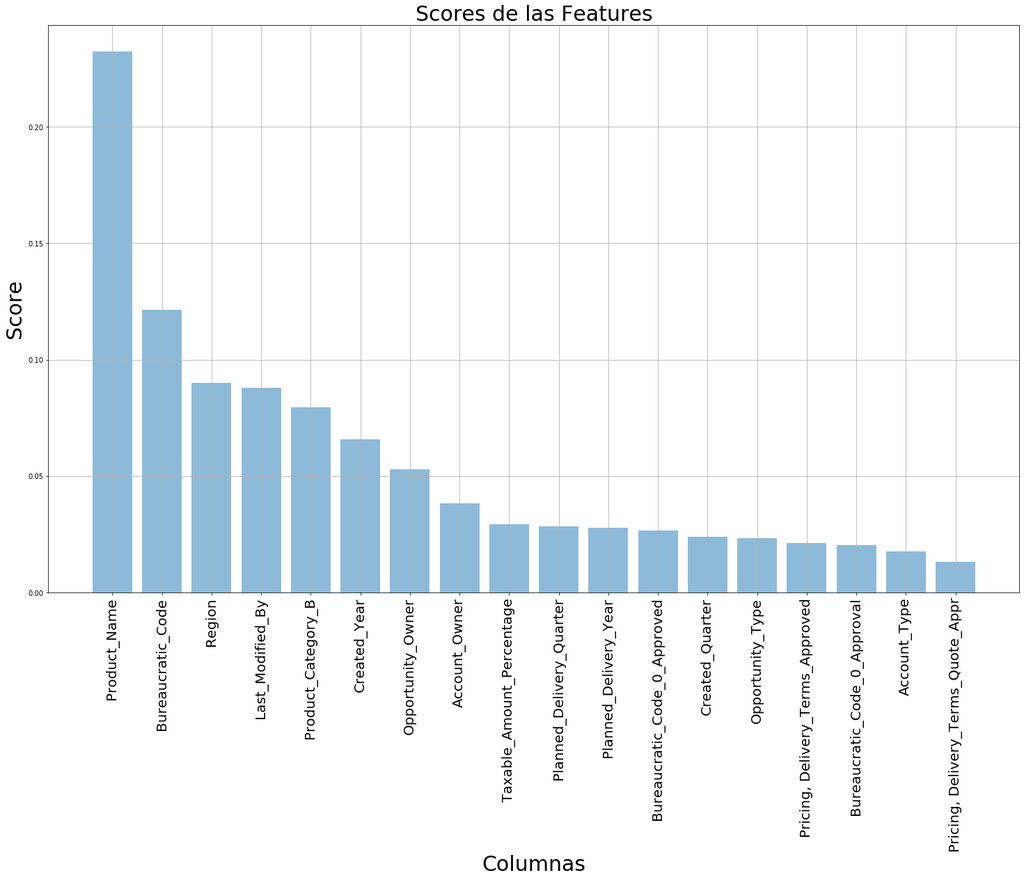

```python
columnas = X_train.columns.array
valores = xgb.feature_importances_
df_scores =pd.DataFrame({'Feat':columnas, 'Score':valores})
df_scores = df_scores.sort_values("Score", ascending = False)
fig, ax = plt.subplots(figsize=(25, 15))


objects = df_scores["Feat"]
y_pos = np.arange(len(objects))
performance = df_scores["Score"]

plt.bar(y_pos, performance, align='center', alpha=0.5)
plt.xticks(y_pos, objects, fontsize =20, rotation = 90)

plt.grid()
plt.title("Scores de las Features", fontsize=30)
plt.xlabel("Columnas", fontsize=30)
plt.ylabel("Score", fontsize=30)

plt.show()
```

# LGB

```python
from lightgbm import LGBMClassifier
```

```python
lgbc = LGBMClassifier(n_estimators=800,max_depth=7, learning_rate=0.0015)
```

```python
lgbc.fit(X_train.values, y_train)
```

```
LGBMClassifier(boosting_type='gbdt', class_weight=None, colsample_bytree=1.0,
               importance_type='split', learning_rate=0.0015, max_depth=7,
               min_child_samples=20, min_child_weight=0.001, min_split_gain=0.0,
               n_estimators=800, n_jobs=-1, num_leaves=31, objective=None,
               random_state=None, reg_alpha=0.0, reg_lambda=0.0, silent=True,
               subsample=1.0, subsample_for_bin=200000, subsample_freq=0)
```

```python
log_loss(y_train, lgbc.predict_proba(X_train.values))
```

```
0.4004407653186274
```

```python
log_loss(y_test, lgbc.predict_proba(X_test.values))
```

```
0.4053939845455257
```

# Log regression

```python
from sklearn.linear_model import LogisticRegression
```

```python
logreg = LogisticRegression(random_state=0, C=0.5).fit(X_train, y_train)
```

```python
log_loss(y_train, logreg.predict_proba(X_train.values))
```

```
0.4412370165758148
```

```python
log_loss(y_test, logreg.predict_proba(X_test.values))
```

```
0.4434722645263051
```

# Adaboost

```python
from sklearn.ensemble import AdaBoostClassifier
from sklearn.tree import DecisionTreeClassifier

adab = AdaBoostClassifier(n_estimators=600,
                          base_estimator=DecisionTreeClassifier(max_depth=4, class_weight='balanced'),
                          random_state=0, learning_rate=0.001)
adab.fit(X_train, y_train)
```

```
AdaBoostClassifier(algorithm='SAMME.R',
                   base_estimator=DecisionTreeClassifier(ccp_alpha=0.0,
                                                         class_weight='balanced',
                                                         criterion='gini',
                                                         max_depth=4,
                                                         max_features=None,
                                                         max_leaf_nodes=None,
                                                         min_impurity_decrease=0.0,
                                                         min_impurity_split=None,
                                                         min_samples_leaf=1,
                                                         min_samples_split=2,
                                                         min_weight_fraction_leaf=0.0,
                                                         presort='deprecated',
                                                         random_state=None,
                                                         splitter='best'),
                   learning_rate=0.001, n_estimators=600, random_state=0)
```

```python
log_loss(y_train, adab.predict_proba(X_train.values))
```

```
0.38516278427848905
```

```python
log_loss(y_test, adab.predict_proba(X_test.values))
```

```
0.3898391548054084
```

# Voting

```python
from sklearn.ensemble import VotingClassifier
```

```python
voting1 = VotingClassifier(estimators=[
        ('adab', adab), ('xgb', xgb), ('lgbc', lgbc), ('logreg',logreg)], voting='soft')
voting1.fit(X_train.values, y_train)
```

```
VotingClassifier(estimators=[('adab',
                              AdaBoostClassifier(algorithm='SAMME.R',
                                                 base_estimator=DecisionTreeClassifier(ccp_alpha=0.0,
                                                                                       class_weight='balanced',
                                                                                       criterion='gini',
                                                                                       max_depth=4,
                                                                                       max_features=None,
                                                                                       max_leaf_nodes=None,
                                                                                       min_impurity_decrease=0.0,
                                                                                       min_impurity_split=None,
                                                                                       min_samples_leaf=1,
                                                                                       min_samples_split=2,
                                                                                       min_weight_fraction_leaf=0.0,
                                                                                       presort='depr...
                                             subsample_for_bin=200000,
                                             subsample_freq=0)),
                             ('logreg',
                              LogisticRegression(C=0.5, class_weight=None,
                                                 dual=False, fit_intercept=True,
                                                 intercept_scaling=1,
                                                 l1_ratio=None, max_iter=100,
                                                 multi_class='auto',
                                                 n_jobs=None, penalty='l2',
                                                 random_state=0, solver='lbfgs',
                                                 tol=0.0001, verbose=0,
                                                 warm_start=False))],
                 flatten_transform=True, n_jobs=None, voting='soft',
                 weights=None)
```

```python
log_loss(y_train, voting1.predict_proba(X_train.values))
```

```
0.36518659420991706
```

```python
log_loss(y_test, voting1.predict_proba(X_test.values))
```

```
0.3715382175398067
```

# SVC

```python
from sklearn.pipeline import make_pipeline
from sklearn.preprocessing import StandardScaler
from sklearn.svm import SVC

svc = make_pipeline(StandardScaler(), SVC(gamma='auto', probability=True, C=0.5))
svc.fit(X_train.values, y_train)
```

```
Pipeline(memory=None,
         steps=[('standardscaler',
                 StandardScaler(copy=True, with_mean=True, with_std=True)),
                ('svc',
                 SVC(C=0.5, break_ties=False, cache_size=200, class_weight=None,
                     coef0=0.0, decision_function_shape='ovr', degree=3,
                     gamma='auto', kernel='rbf', max_iter=-1, probability=True,
                     random_state=None, shrinking=True, tol=0.001,
                     verbose=False))],
         verbose=False)
```

```python
log_loss(y_train, svc.predict_proba(X_train.values))
```

```
0.3198362297029001
```

```python
log_loss(y_test, svc.predict_proba(X_test.values))
```

```
0.3284617524777899
```

# SGD

```python
from sklearn.linear_model import SGDClassifier

sgd = make_pipeline(StandardScaler(),
                    SGDClassifier(max_iter=3000, tol=1e-3, class_weight='balanced', n_jobs=-1, loss='log'))
sgd.fit(X_train.values, y_train)
```

```
Pipeline(memory=None,
         steps=[('standardscaler',
                 StandardScaler(copy=True, with_mean=True, with_std=True)),
                ('sgdclassifier',
                 SGDClassifier(alpha=0.0001, average=False,
                               class_weight='balanced', early_stopping=False,
                               epsilon=0.1, eta0=0.0, fit_intercept=True,
                               l1_ratio=0.15, learning_rate='optimal',
                               loss='log', max_iter=3000, n_iter_no_change=5,
                               n_jobs=-1, penalty='l2', power_t=0.5,
                               random_state=None, shuffle=True, tol=0.001,
                               validation_fraction=0.1, verbose=0,
                               warm_start=False))],
         verbose=False)
```

```python
log_loss(y_train, sgd.predict_proba(X_train.values))
```

```
0.419720406520451
```

```python
log_loss(y_test, sgd.predict_proba(X_test.values))
```

```
0.4210282344624034
```

# Stacking

```python
from sklearn.ensemble import StackingClassifier

estimators = [
    ('sgd', sgd),
    ('svc',svc),
    ('logreg',logreg)
]
stacking1 = StackingClassifier(
    estimators=estimators, final_estimator=LogisticRegression()
)
stacking1.fit(X_train.values, y_train).score(X_test.values, y_test)
```

```
0.8676737160120845
```

```python
log_loss(y_train, stacking1.predict_proba(X_train.values))
```

```
0.33195607269208816
```

```python
log_loss(y_test, stacking1.predict_proba(X_test.values))
```

```
0.33955772917401605
```

# Final Stacking

```python
estimators = [
    ('voting1',voting1),
    ('stacking1', stacking1)
]
final_stack = StackingClassifier(
    estimators=estimators, final_estimator=LogisticRegression()
)
final_stack.fit(X_train.values, y_train).score(X_test.values, y_test)
```

```
0.8598187311178248
```

```python
log_loss(y_train, final_stack.predict_proba(X_train.values))
```

```
0.3271687725029524
```

```python
log_loss(y_test, final_stack.predict_proba(X_test.values))
```

```
0.33706089412689244
```

# Final Voting

```python
final_voting = VotingClassifier(estimators=[('voting1',voting1),('stacking1', stacking1)], voting='soft')
final_voting.fit(X_train.values, y_train)
```

```
VotingClassifier(estimators=[('voting1',
                              VotingClassifier(estimators=[('adab',
                                                            AdaBoostClassifier(algorithm='SAMME.R',
                                                                               base_estimator=DecisionTreeClassifier(ccp_alpha=0.0,
                                                                                                                     class_weight='balanced',
                                                                                                                     criterion='gini',
                                                                                                                     max_depth=4,
                                                                                                                     max_features=None,
                                                                                                                     max_leaf_nodes=None,
                                                                                                                     min_impurity_decrease=0.0,
                                                                                                                     min_impurity_split=None,
                                                                                                                     min_samples_leaf=1,
                                                                                                                     min_samples_split=2,
                                                                                                                     mi...
                                                 final_estimator=LogisticRegression(C=1.0,
                                                                                    class_weight=None,
                                                                                    dual=False,
                                                                                    fit_intercept=True,
                                                                                    intercept_scaling=1,
                                                                                    l1_ratio=None,
                                                                                    max_iter=100,
                                                                                    multi_class='auto',
                                                                                    n_jobs=None,
                                                                                    penalty='l2',
                                                                                    random_state=None,
                                                                                    solver='lbfgs',
                                                                                    tol=0.0001,
                                                                                    verbose=0,
                                                                                    warm_start=False),
                                                 n_jobs=None, passthrough=False,
                                                 stack_method='auto',
                                                 verbose=0))],
                 flatten_transform=True, n_jobs=None, voting='soft',
                 weights=None)
```

```python
log_loss(y_train, final_voting.predict_proba(X_train.values))
```

```
0.33619391261729914
```

```python
log_loss(y_test, final_voting.predict_proba(X_test.values))
```

```
0.34294978707897567
```

# Voting 2

```python
estimators = [('adab', adab),
              ('xgb', xgb),
              ('sgd', sgd),
              ('logreg',logreg),
              ('lgbc', lgbc)]

voting2 = VotingClassifier(estimators=estimators, voting='soft')
voting2.fit(X_train.values, y_train)
```

```
VotingClassifier(estimators=[('adab',
                              AdaBoostClassifier(algorithm='SAMME.R',
                                                 base_estimator=DecisionTreeClassifier(ccp_alpha=0.0,
                                                                                       class_weight='balanced',
                                                                                       criterion='gini',
                                                                                       max_depth=4,
                                                                                       max_features=None,
                                                                                       max_leaf_nodes=None,
                                                                                       min_impurity_decrease=0.0,
                                                                                       min_impurity_split=None,
                                                                                       min_samples_leaf=1,
                                                                                       min_samples_split=2,
                                                                                       min_weight_fraction_leaf=0.0,
                                                                                       presort='depr...
                                             importance_type='split',
                                             learning_rate=0.0015, max_depth=7,
                                             min_child_samples=20,
                                             min_child_weight=0.001,
                                             min_split_gain=0.0,
                                             n_estimators=800, n_jobs=-1,
                                             num_leaves=31, objective=None,
                                             random_state=None, reg_alpha=0.0,
                                             reg_lambda=0.0, silent=True,
                                             subsample=1.0,
                                             subsample_for_bin=200000,
                                             subsample_freq=0))],
                 flatten_transform=True, n_jobs=None, voting='soft',
                 weights=None)
```

```python
log_loss(y_train, voting2.predict_proba(X_train.values))
```

```
0.3673959924479824
```

```python
log_loss(y_test, voting2.predict_proba(X_test.values))
```

```
0.3723311904312096
```

# Stacking 2

```python
estimators = [('adab', adab),
              ('xgb', xgb),
              ('svc',svc),
              ('sgd', sgd),
              ('logreg',logreg),
              ('lgbc', lgbc)]

stacking2 = StackingClassifier(estimators=estimators, final_estimator=LogisticRegression())
stacking2.fit(X_train.values, y_train)
```

```
StackingClassifier(cv=None,
                   estimators=[('adab',
                                AdaBoostClassifier(algorithm='SAMME.R',
                                                   base_estimator=DecisionTreeClassifier(ccp_alpha=0.0,
                                                                                         class_weight='balanced',
                                                                                         criterion='gini',
                                                                                         max_depth=4,
                                                                                         max_features=None,
                                                                                         max_leaf_nodes=None,
                                                                                         min_impurity_decrease=0.0,
                                                                                         min_impurity_split=None,
                                                                                         min_samples_leaf=1,
                                                                                         min_samples_split=2,
                                                                                         min_weight_fraction_leaf=0.0,
                                                                                         pre...
                                               subsample_for_bin=200000,
                                               subsample_freq=0))],
                   final_estimator=LogisticRegression(C=1.0, class_weight=None,
                                                      dual=False,
                                                      fit_intercept=True,
                                                      intercept_scaling=1,
                                                      l1_ratio=None,
                                                      max_iter=100,
                                                      multi_class='auto',
                                                      n_jobs=None, penalty='l2',
                                                      random_state=None,
                                                      solver='lbfgs',
                                                      tol=0.0001, verbose=0,
                                                      warm_start=False),
                   n_jobs=None, passthrough=False, stack_method='auto',
                   verbose=0)
```

```python
log_loss(y_train, stacking2.predict_proba(X_train.values))
```

```
0.2853414621376653
```

```python
log_loss(y_test, stacking2.predict_proba(X_test.values))
```

```
0.3050587773160681
```

# Re-entreno con todo el set de entrenamiento

```python
if 'Opportunity_ID' not in drop_features:
    drop_features.append('Opportunity_ID')
```

```python
train = train_preprocessing_pipeline.fit_transform(df)
```

```python
train = preprocessing_pipeline.fit_transform(train)
```

```python
X = train.drop('Stage',axis=1)
y = train['Stage']
```

```python
X.head()
```

|  | Region | Pricing, Delivery_Terms_Quote_Appr | Pricing, Delivery_Terms_Approved | Bureaucratic_Code_0_Approval | Bureaucratic_Code_0_Approved | Bureaucratic_Code | Account_Owner | Opportunity_Owner | Account_Type | Opportunity_Type | Product_Category_B | Last_Modified_By | Product_Name | Taxable_Amount_Percentage | Created_Year | Created_Quarter | Planned_Delivery_Year | Planned_Delivery_Quarter |
| --- | --- | --- | --- | --- | --- | --- | --- | --- | --- | --- | --- | --- | --- | --- | --- | --- | --- | --- |
| 0 | 0.532269 | 1 | 1 | 1 | 1 | 0.652443 | 0.409524 | 0.561350 | 0.540816 | 0.532074 | 0 | 0.472477 | 0.186992 | 1.0 | 2015 | 4 | 2016 | 2 |
| 1 | 0.532269 | 0 | 0 | 0 | 0 | 0.652443 | 0.409524 | 0.750000 | 0.540816 | 0.532074 | 0 | 0.523810 | 0.589529 | 1.0 | 2015 | 4 | 2016 | 1 |
| 2 | 0.459008 | 0 | 0 | 0 | 0 | 0.652443 | 0.688406 | 0.595272 | 0.302646 | 0.532074 | 0 | 0.506173 | 0.899958 | 1.0 | 2015 | 4 | 2016 | 1 |
| 3 | 0.459008 | 1 | 0 | 1 | 0 | 0.271651 | 0.594828 | 0.595272 | 0.302646 | 0.214014 | 1 | 0.506173 | 0.009174 | 1.0 | 2015 | 4 | 2018 | 1 |
| 4 | 0.459008 | 1 | 0 | 1 | 0 | 0.271651 | 0.594828 | 0.595272 | 0.302646 | 0.214014 | 1 | 0.506173 | 0.009174 | 1.0 | 2015 | 4 | 2018 | 1 |

```python
X.shape
```

```
(16522, 18)
```

```python
adab.fit(X.values, y)
```

```
AdaBoostClassifier(algorithm='SAMME.R',
                   base_estimator=DecisionTreeClassifier(ccp_alpha=0.0,
                                                         class_weight='balanced',
                                                         criterion='gini',
                                                         max_depth=4,
                                                         max_features=None,
                                                         max_leaf_nodes=None,
                                                         min_impurity_decrease=0.0,
                                                         min_impurity_split=None,
                                                         min_samples_leaf=1,
                                                         min_samples_split=2,
                                                         min_weight_fraction_leaf=0.0,
                                                         presort='deprecated',
                                                         random_state=None,
                                                         splitter='best'),
                   learning_rate=0.001, n_estimators=600, random_state=0)
```

```python
log_loss(y, adab.predict_proba(X.values))
```

```
0.38723128362297743
```

# Set de validación

```python
date_cols = ['Account_Created_Date',
            'Opportunity_Created_Date',
            'Last_Activity',
            'Quote_Expiry_Date',
            'Last_Modified_Date',
            'Planned_Delivery_Start_Date',
            'Planned_Delivery_End_Date']
val = pd.read_csv('./data/val.csv', parse_dates=date_cols)
```

```python
if 'Opportunity_ID' in drop_features:
    drop_features.remove('Opportunity_ID')
```

```python
val_prep = preprocessing_pipeline.transform(val.drop('Opportunity_ID',axis=1))
```

```python
val_prep.head()
```

|  | Region | Pricing, Delivery_Terms_Quote_Appr | Pricing, Delivery_Terms_Approved | Bureaucratic_Code_0_Approval | Bureaucratic_Code_0_Approved | Bureaucratic_Code | Account_Owner | Opportunity_Owner | Account_Type | Opportunity_Type | Product_Category_B | Last_Modified_By | Product_Name | Taxable_Amount_Percentage | Created_Year | Created_Quarter | Planned_Delivery_Year | Planned_Delivery_Quarter |
| --- | --- | --- | --- | --- | --- | --- | --- | --- | --- | --- | --- | --- | --- | --- | --- | --- | --- | --- |
| 0 | 0.532269 | 1 | 1 | 1 | 1 | 0.652443 | 0.672453 | 0.664537 | 0.701748 | 0.706694 | 0 | 0.609375 | 0.562220 | 0.441567 | 2019 | 2 | 2019 | 2 |
| 1 | 0.532269 | 1 | 1 | 1 | 1 | 0.652443 | 0.672453 | 0.664537 | 0.701748 | 0.706694 | 0 | 0.609375 | 0.500057 | 0.213990 | 2019 | 2 | 2019 | 2 |
| 2 | 0.532269 | 1 | 1 | 1 | 1 | 0.652443 | 0.672453 | 0.664537 | 0.701748 | 0.706694 | 0 | 0.609375 | 0.752351 | 0.344443 | 2019 | 2 | 2019 | 2 |
| 3 | 0.532269 | 1 | 1 | 1 | 1 | 0.652443 | 0.672453 | 0.664537 | 0.701748 | 0.706694 | 0 | 0.609375 | 0.562220 | 0.321147 | 2019 | 2 | 2019 | 2 |
| 4 | 0.532269 | 1 | 1 | 1 | 1 | 0.652443 | 0.672453 | 0.664537 | 0.701748 | 0.706694 | 0 | 0.609375 | 0.500057 | 0.207510 | 2019 | 2 | 2019 | 2 |

```python
val_preds = adab.predict_proba(val_prep.values)
```

```python
subm = pd.DataFrame({'id':val.Opportunity_ID, 'target':val_preds[:,1]})
```

```python
subm = subm.groupby(by='id').max()
```

```python
subm.to_csv("subm.csv", index=True, header=False)
```